# Data Analysis Task

Abdelrahman

2023-05-04

## Task detailes

- Access this public type 2 diabetes (T2D) metabolomics dataset: https://figshare.com/articles/Qatar_Metabolomics_Study_on_Diabetes/5904022 o Download the preprocessed plasma metabolomics data and annotations from QMDiab_metabolomics_Preprocessed.xlsx o In the data matrix, rows represent blood samples from study participants, and columns contain measured metabolites o Note that the first column of this table contains sample IDs, and the last 5 columns contain clinical variables.
- Visualize the entire dataset with one or more plots of your choice. Explain why you chose these plots and what you observe in the data.
- Run a differential abundance analysis between participants with and without diabetes. o We want to model met ~ T2D + age + gender + BMI for each metabolite met using linear regression. We are interested in the p-value of the effect of T2D on each metabolite. o Visualize the results of this statistical test using a plot of your choice.
- Biological interpretation: Give some insights into the metabolites that came out of this analysis. What are those? What does that tell us about type 2 diabetes?

```r
library(openxlsx)
library(dplyr)
```

```r
library("pheatmap")
library("RColorBrewer")
library(ggplot2)
```

## Load Data

```r
plasma <- read.xlsx("D:/CV/Krumsiek_task/QMDiab_metabolomics_Preprocessed.xlsx" , sheet = "plasma")

plsma_annotation <- read.xlsx("D:/CV/Krumsiek_task/QMDiab_metabolomics_Preprocessed.xlsx" , sheet = "plasma annotations")
```

### HeatMap

a great way to visualize the abundance of metabolites across different samples. They can provide an overview of the data and help identify patterns or clusters of metabolites that are co-regulated or have similar profiles across conditions

```r
#copy the original data
data_heatmap <- plasma
#change rownaames
rownames(data_heatmap)<-plasma$`QMDiab-ID`
#extract the T2D column values for using in the annotation of heatmap while 0 -> N and 1-> Y
T2D <- data.frame( T2D = ifelse(grepl("1",data_heatmap$T2D),
                                    "Y","N"),
                     row.names = row.names(data_heatmap))

#select the whole data set except the clinical data
data_heatmap <- data_heatmap[,-c(1 ,c(501:507))]
```

### Normality check using shapiro test for chossing Appropriate correlation method

```r
#calculate the mean for each metabolite
means <- data.frame(apply(data_heatmap, 1, mean))
#shapiro test
shapiro.test(means$apply.data_heatmap..1..mean.)
```

```
##
##  Shapiro-Wilk normality test
##
## data:  means$apply.data_heatmap..1..mean.
## W = 0.99497, p-value = 0.3007
```

the data are parametric because of p_value is greater than 0.05

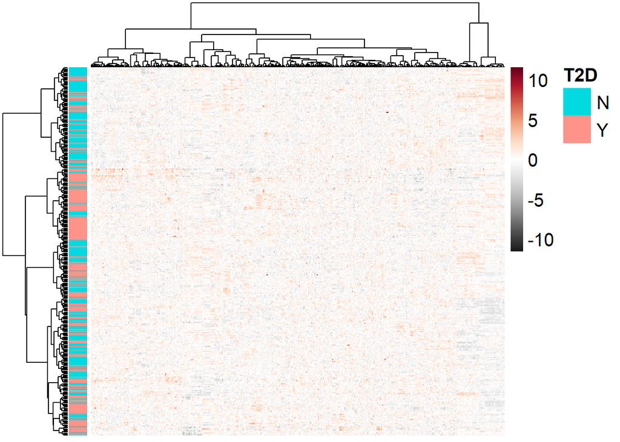

```r
pheatmap(as.matrix(data_heatmap)  ,
         scale = "column",
         clustering_distance_rows = "correlation", #using pearson correlation for parametric data
         clustering_distance_cols = "correlation" ,
         clustering_method = "ward.D", #to minimize the variance between clusters
         fontsize = 15,  color =  rev(colorRampPalette(brewer.pal(11, "RdGy"))(256)),
         angle_col = 45 , na_col = "grey",
         cluster_cols = T , cluster_rows = T,
         #filename = "myheatmap_2.png",
         annotation_row  = T2D,
         annotation_names_row  = F,
         show_rownames = F , show_colnames = F
)
```

this plot shows some metabolites that have clustered together in the upper right corner and another in the middle, but because of the overview of the entire data which has huge sample size the patterns or clusters are not clear from the first shot but the statistical test will provide the evidence for this pattern

# Histograme

provide a visual representation of the distribution of the data and confirm the interpretation of shapiro test that the data is parametric and normal distributed

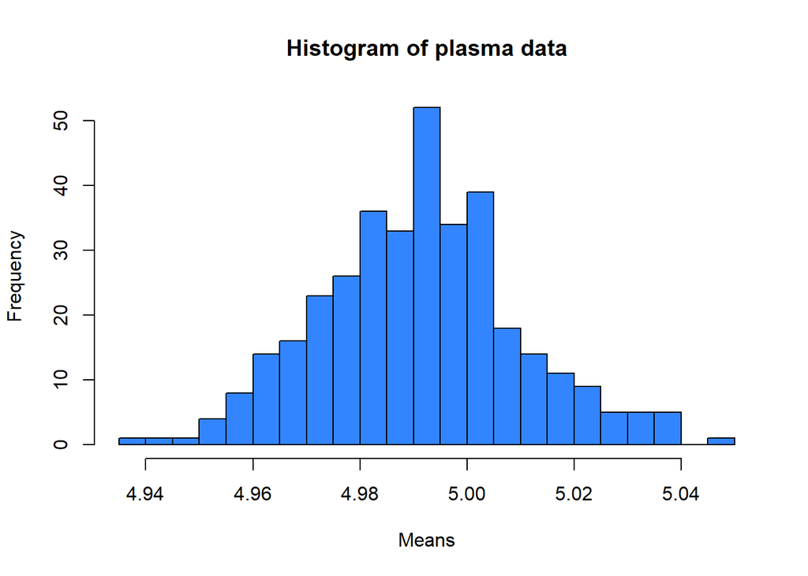

## linear regression

```r
#copy the daataframe
plasma_reg <- plasma
#make the samples as rownames for easy to use
rownames(plasma_reg)<-plasma_reg$`QMDiab-ID`
#delete the sample ids column
plasma_reg<- plasma_reg[,-c(1)]
#empty vector to store the p-values
p_values <-rep(NA, ncol(plasma_reg[,-c(501:507)]))

#loop over each metabolite and use it in the linear regression model fromula
#And extract the p-value for T2D for each metabolites
# store it in the p-value vector
for(i in 1:ncol(plasma_reg[,-c(501:507)])){
  met <- plasma_reg[,i]

  model <- lm(met ~ T2D + AGE + GENDER + BMI
            , data =plasma_reg )
  p_values[i] <- summary(model)$coefficients[2, 4]

}
```

## significant metabolities

```r
#create new data frame and adding p-values
significants <-cbind(data.frame(t(plasma_reg[,-c(501:507)])) , p_values)
#select p-values with metabolites in rownames
significants_pvalue <- significants %>% dplyr::select(p_values)
```

## Scatter plot for significant metabolities

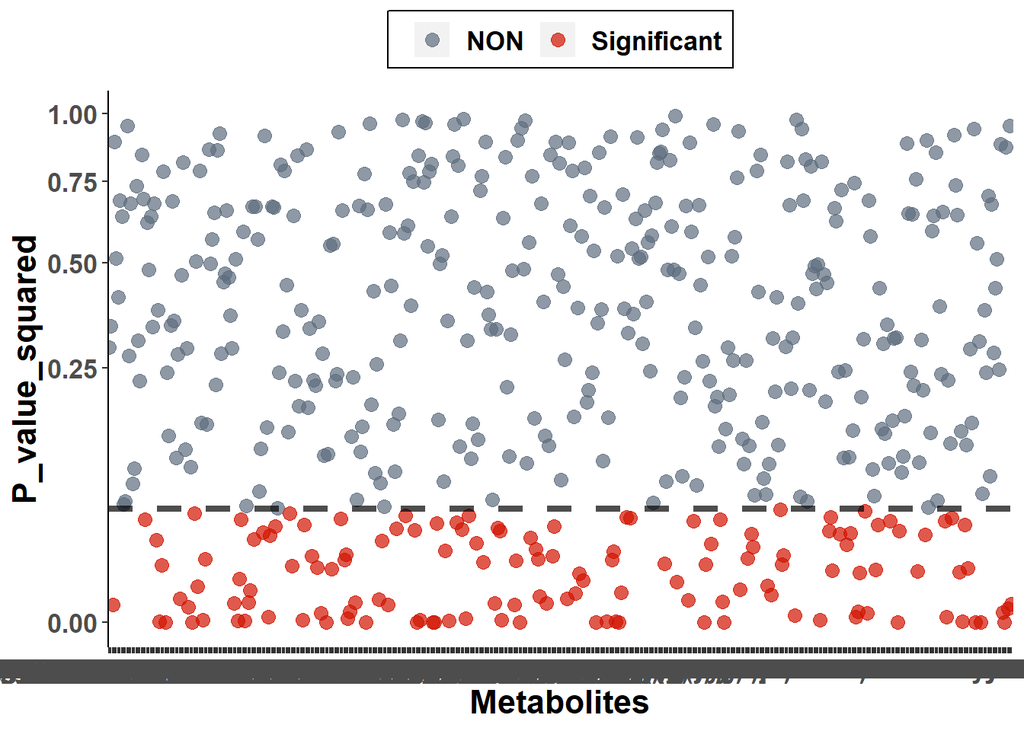

```r
#add color column to determine the significant metabolities in the whole data set
significants_pvalue$color <- ifelse(significants_pvalue$p_values < 0.05 , "Significant", "NON")


ggplot(significants_pvalue , aes(y = p_values , x = rownames(significants_pvalue), colour = color)) +
   geom_point(size = 3, alpha = 0.7) +
  theme(legend.background = element_rect( linetype="solid",colour ="black")) +
  theme( axis.line.y = element_line(colour = "black",linetype = "solid")) +
  theme(legend.position="top" , legend.title=element_blank()) +
  theme(text=element_text(size=16, face = "bold")) +
  scale_color_manual(values=c("#5D6D7E","#D11300" )) +
  theme(  panel.background = element_rect(fill = "white", colour = "white")) +
  scale_fill_discrete(name = "") +
  geom_hline(yintercept= 0.05, size=1.5, linetype="dashed", alpha=0.7) +
  xlab("Metabolites") +
  ylab("P_value_squared") + scale_y_sqrt() #for maximize scale of the data
```

### plot shows the number of significant metabolites according to the p-values extracted based on the linear regression formula is 139 out of 500

## Significant Metabolites

```r
#select any  metabolite that have p-value less than 0.05 -> 139
significant_met <- significants[which(p_values< 0.05),]
#search  in the annotation sheet about the significant metabolites and its pathways -> 71
annotation <- plsma_annotation[which(rownames(significant_met) %in% plsma_annotation$BIOCHEMICAL ), ]

annotation$BIOCHEMICAL
```

```
##  [1] "1,11-Undecanedicarboxylic acid"
##  [2] "1,2-dipalmitoylglycerol"
##  [3] "1,2-propanediol"
##  [4] "1,3-dihydroxyacetone"
##  [5] "1,3-dipalmitoylglycerol"
##  [6] "1,5-anhydroglucitol (1,5-AG)"
##  [7] "1,7-dimethylurate"
##  [8] "1-docosahexaenoylglycerophosphocholine*"
##  [9] "1-docosapentaenoylglycerophosphocholine*"
## [10] "1-eicosadienoylglycerophosphocholine*"
## [11] "1-eicosatrienoylglycerophosphocholine*"
## [12] "1-heptadecanoylglycerophosphocholine"
## [13] "1-linoleoylglycerophosphocholine"
## [14] "1-linoleoylglycerophosphoethanolamine*"
## [15] "1-methylxanthine"
```

[output cut: 56 more lines]

### The number of significant metabolites that I found information about in the annotation set are 71 metabolites

## Biological insights

### What are those Metabolites ?

For example, 1,5-anhydroglucitol (1,5-AG) is a marker of short-term glycemic control and has been shown to be lower in people with diabetes, indicating a potential role in the pathogenesis of the disease. Similarly, changes in the metabolism of fatty acids and their derivatives, such as 1,2-dipalmitoylglycerol and 1-oleoylglycerophosphocholine, have been linked to insulin resistance and impaired glucose metabolism, which are key features of type 2 diabetes.

Other metabolites on the list may have more indirect associations with type 2 diabetes, such as 3-indoxyl sulfate, which is produced by gut bacteria and has been linked to insulin resistance and inflammation. Additionally, some metabolites on the list may be related to secondary complications of diabetes, such as 4-hydroxyhippurate, which has been associated with diabetic nephropathy.

### What does that tell us about type 2 diabetes?

Fatty acids and their metabolites, such as diacylglycerol, have been shown to contribute to insulin resistance and impaired glucose metabolism, which are key features of type 2 diabetes. Elevated levels of ketone bodies have also been linked to insulin resistance and impaired glucose metabolism, as well as increased inflammation and oxidative stress, which can further contribute to the development of type 2 diabetes.

Changes in glycolysis, gluconeogenesis, and pyruvate metabolism have also been observed in people with type 2 diabetes. These metabolic pathways are involved in the production and breakdown of glucose, and alterations in their activity can lead to hyperglycemia and impaired glucose tolerance.

Xanthine metabolism has been implicated in the development of oxidative stress, which can damage cells and tissues and contribute to the development of diabetes-related complications. Lysolipids, which are produced from the hydrolysis of phospholipids, have been shown to be elevated in people with insulin resistance and type 2 diabetes.

Changes in amino acid metabolism, including the metabolism of phenylalanine, tyrosine, and tryptophan, have also been observed in people with type 2 diabetes. These changes can contribute to insulin resistance and impair glucose metabolism.

## References :

https://pubmed.ncbi.nlm.nih.gov/22340217/

https://pubs.rsc.org/en/content/articlehtml/2019/ra/c9ra05046a

https://lipidworld.biomedcentral.com/articles/10.1186/s12944-020-01286-8

https://www.ncbi.nlm.nih.gov/pmc/articles/PMC3730126/

https://www.sciencedirect.com/science/article/pii/S221138351200086X

https://www.amboss.com/us/knowledge/Glycolysis_and_gluconeogenesis/

https://www.mdpi.com/1422-0067/23/19/11177/pdf

https://www.ncbi.nlm.nih.gov/pmc/articles/PMC8914294/

https://www.ncbi.nlm.nih.gov/pmc/articles/PMC7473660/

https://www.sciencedirect.com/science/article/pii/S0731708521004921

https://www.nature.com/articles/s41598-022-11970-7